# 3SB - Offense Report

# Match-level statistics

All of the statistics are only for the O1 line, not O2 or other rotations.

## Points played per match

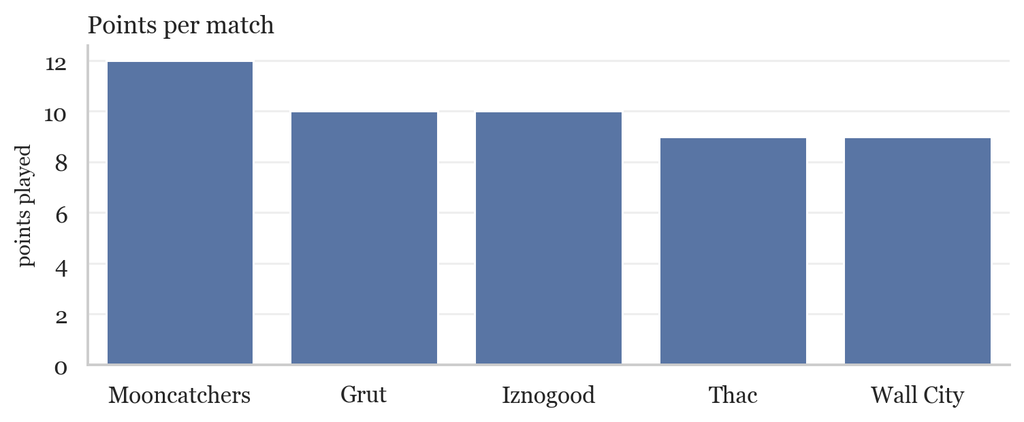

## Turnovers per match

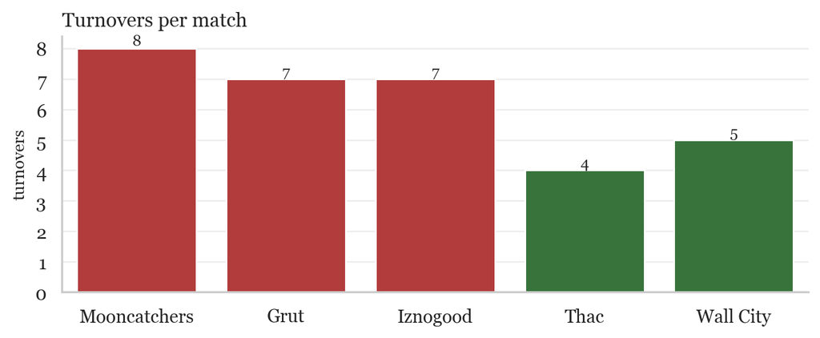

## Pass completion rate per match

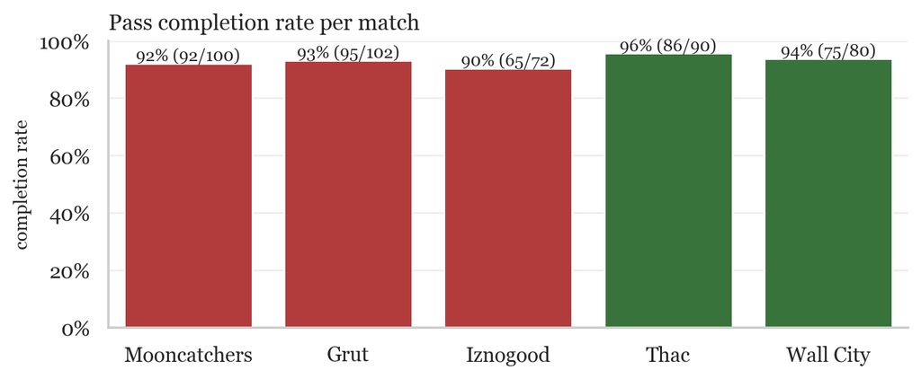

## Scoring efficiency - points per possession

Possession: a series of passes until a turnover.

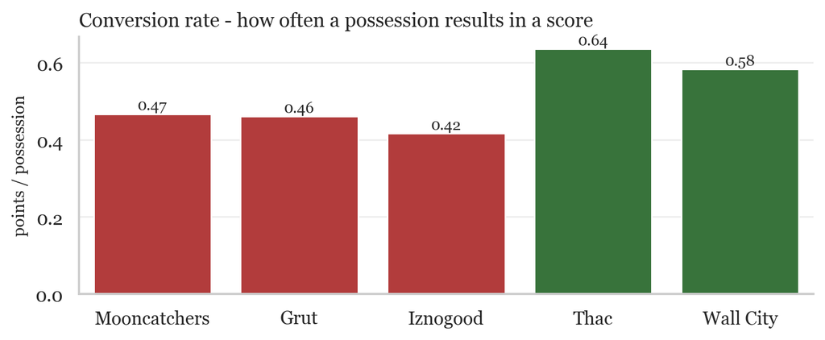

## Passes per successful possession

Average number of passes in a possession that ended in a score.

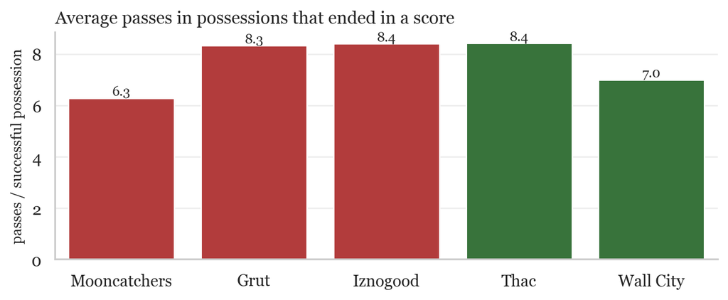

## Break rate

Percentage of O points that ended in a break per match.

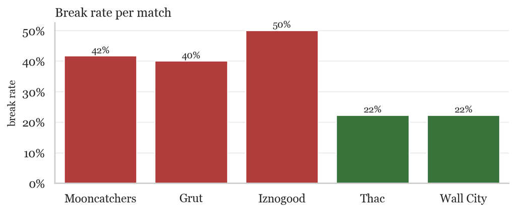

## Clean holds

Percentage of points where we scored without a single turnover.

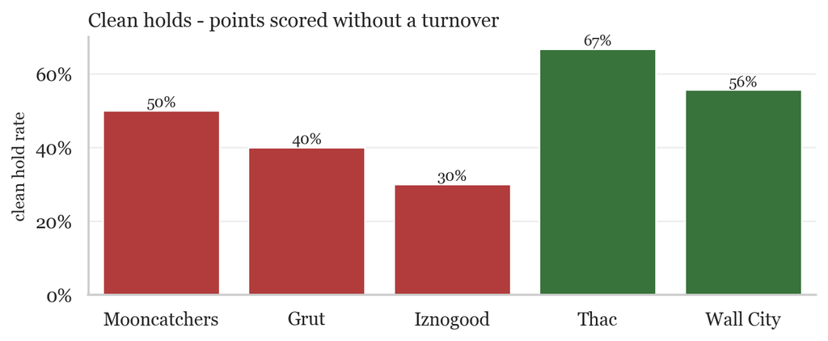

## Recovery rate

Percentage of points where there was at least one turnover and we scored (how much did we take the disc back).

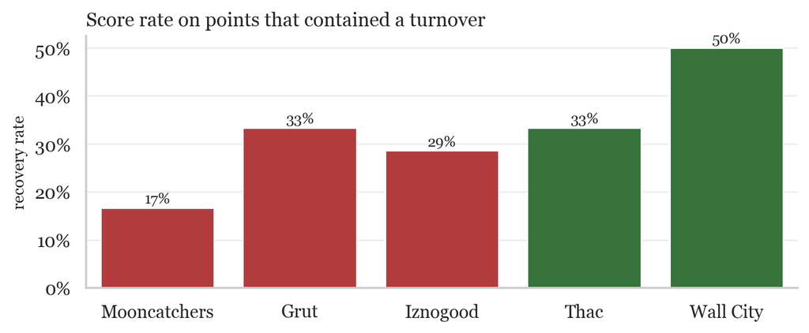

# Pass analysis

Passes below are flipped to be in a single offensive direction (left to right). A *huck* is a pass that is at least as long as 50% of the in-field (the field minus the two endzones).

## Red-zone turnover rate

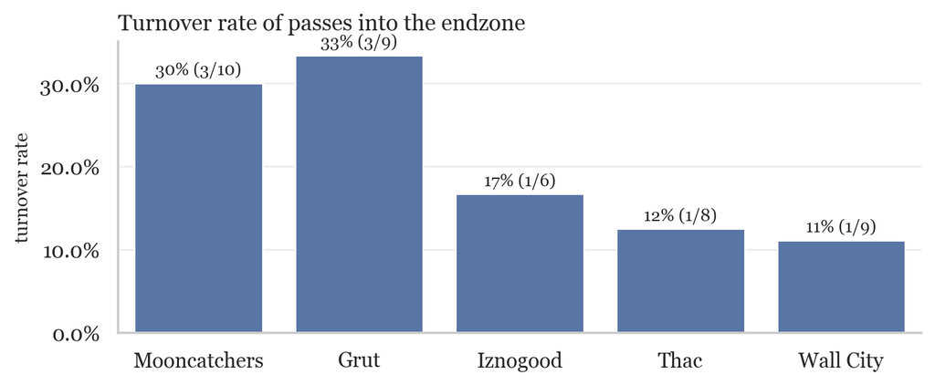

## Hucks per game and their turnover rate

Same-third hucks are hucks that originate and end in the same third of the field, only the two border thirds are considered.

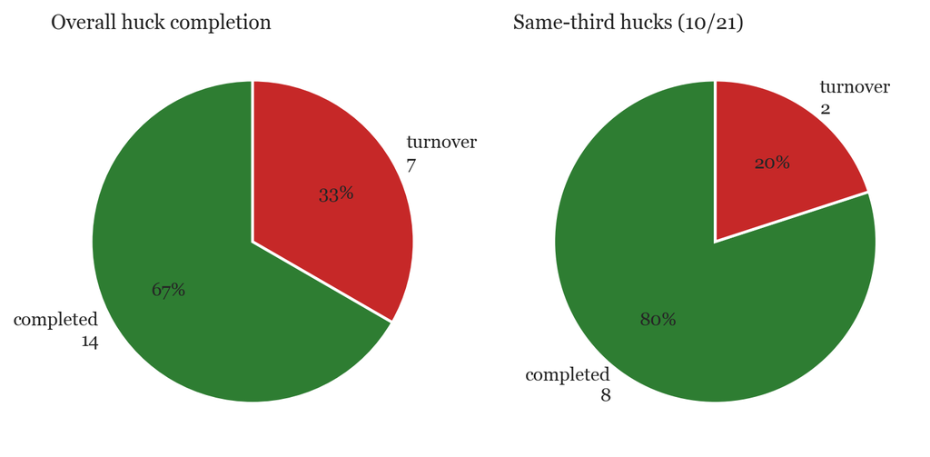

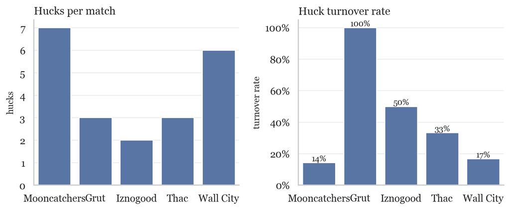

## Huck map - completed vs. turnover

Again, passes are normalized so offense always attacks left to right. Completed vs turnover hucks.

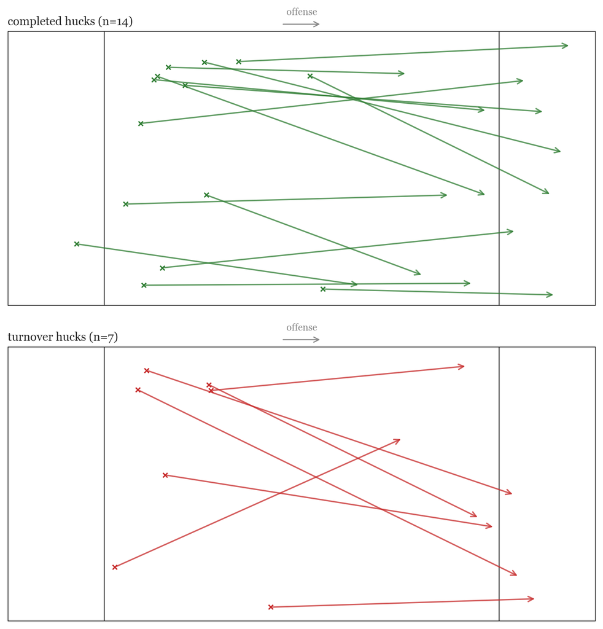

## Huck completion rate by origin

Field divided into a grid, cells show how often a huck thrown from that area was completed. Cells with no hucks are gray. Labels hold the `completed / total` ratio.

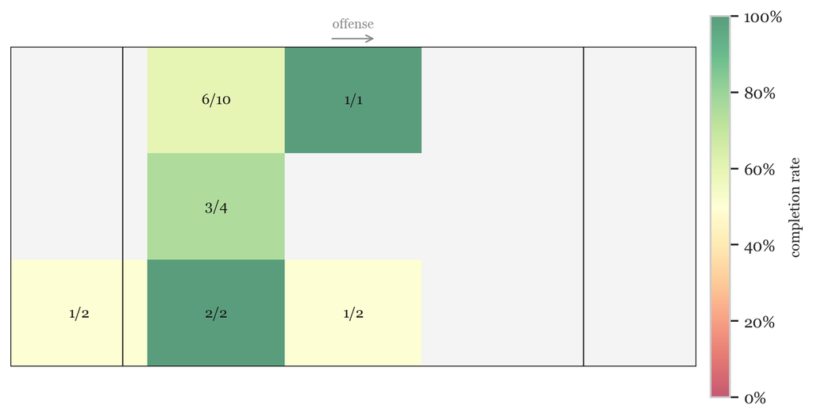

## Turnover rate by pass direction (forward vs backward)

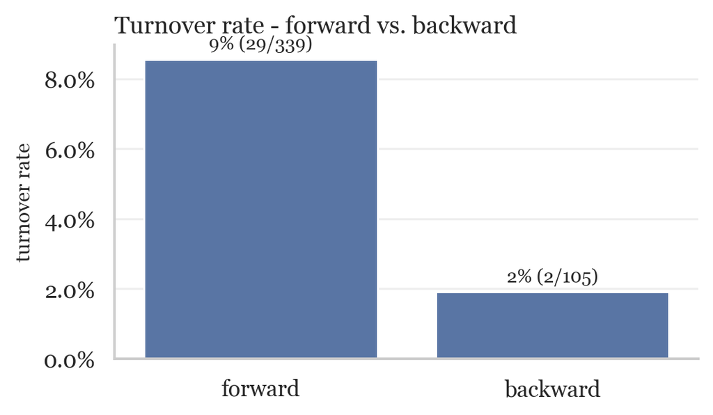

## Turnover breakdown - mechanical, huck, other

We noted when a turnover was mechanical (= a poorly executed throw, “osobní chyba, zához”), not a decision-making or system error or a good defensive effort.

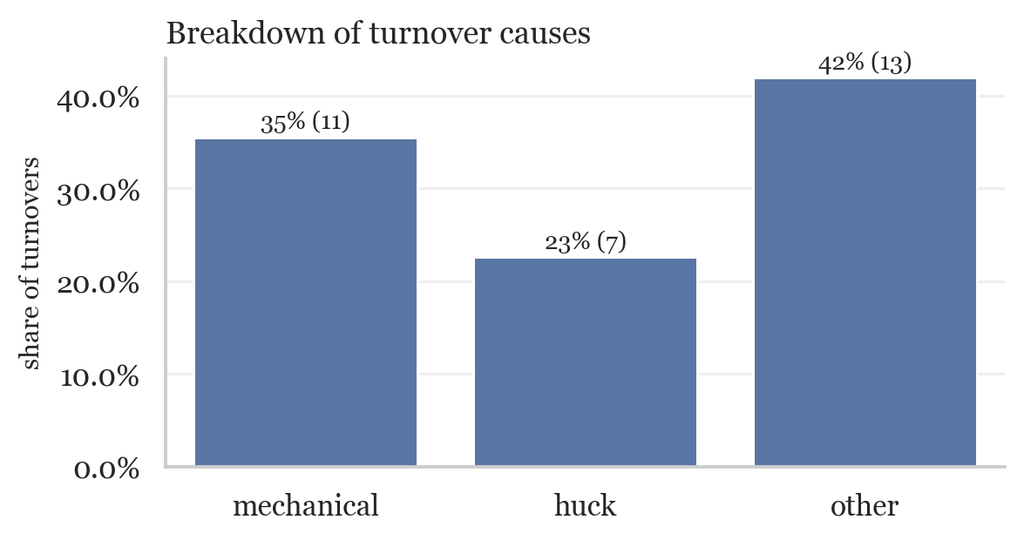

# Turnover heat-maps

O is left to right again. Darker = more likely a turnover happens in that region.

## Origin - where turnovers are *thrown from*

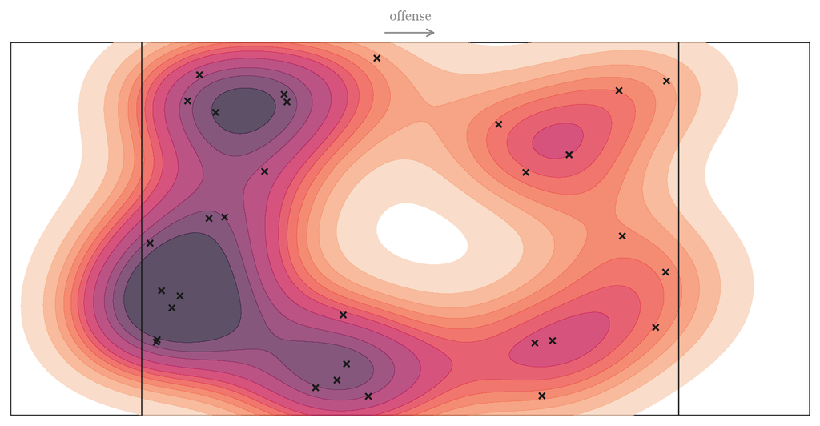

## Destination - where passes that are turnovers *are thrown to*

The intended (or actual) target location of every turnover pass.

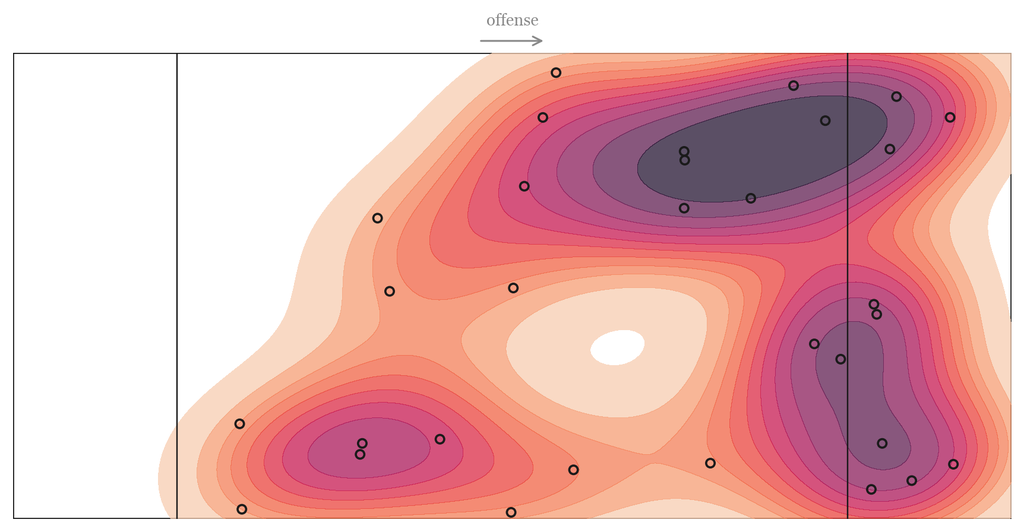

## Arrows - every turnover

Each turnover pass drawn as a red arrow from origin to destination, with the attacking direction unified to the right.

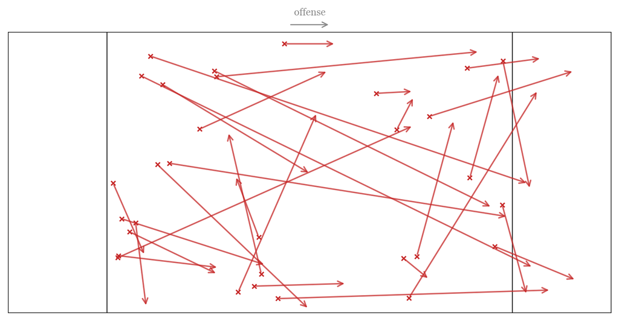

## Turnover origin by field quarter

Field split into four horizontal quarters; each shaded by the share of turnovers whose origin are inside it.

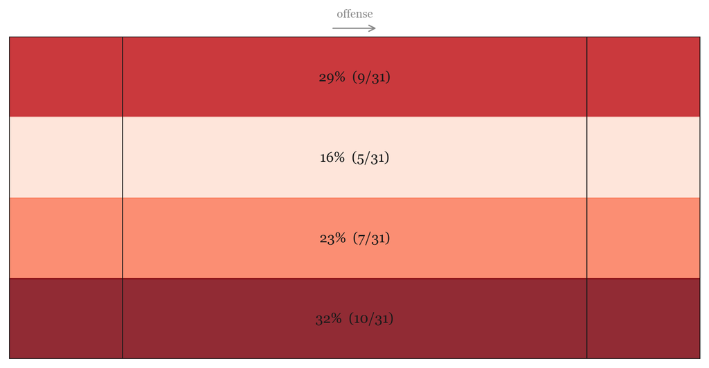

## Pass completion rate by field quarter

Field split into four horizontal quarters; each shaded by the completion rate of passes whose origin are inside it.

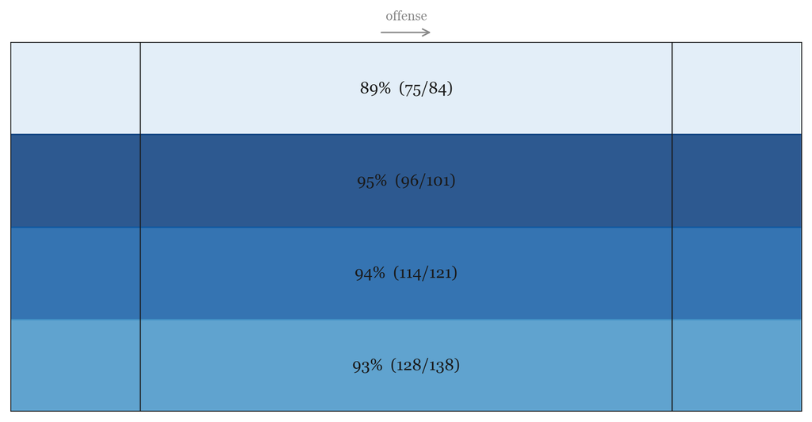

# Pass-distance distribution

Distribution of pass horizontal span - completed vs. turnovers. Dashed line marks the huck threshold.

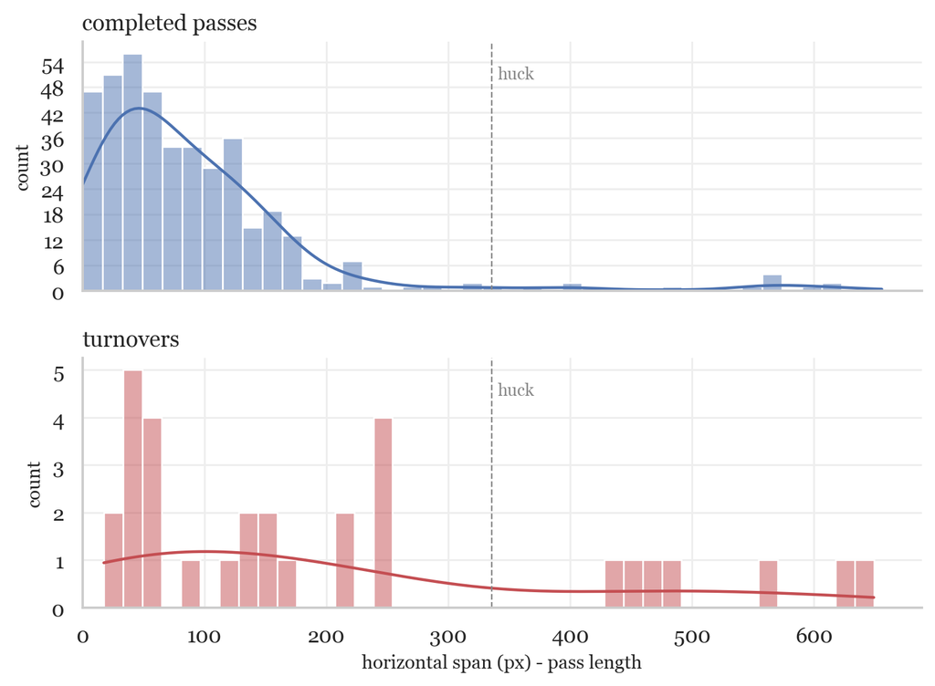